# PLeon_Unit6CaseStudy

Paola Leon

June 15, 2016

## Introduction

The purpose of this document is to analyze the Gross Domestic Product (GDP) among economies with confirmed GDP estimates only. The data includes observations for the year of 2012 (mainly) but can include data for 2011 or 2010 in some cases. The study focuses in understanding the different GDP rankings, quantiles and the correlation that exists (if any) with the Income Groups defined in the World Bank EdStats data.

Original data sources can be found in the links below:

http://data.worldbank.org/data-catalog/GDP-ranking-table

http://data.worldbank.org/data-catalog/ed-stats

# Set the working directory

```r
setwd("/Users/paolaleon/Desktop/MSDS 6303 Doing Data Science/Unit6CaseStudy")
getwd()
```

```
## [1] "/Users/paolaleon/Desktop/MSDS 6303 Doing Data Science/Unit6CaseStudy"
```

# Download datasources.

1. If needed first install and load the “downloader” packages using the following code:

install.packages(“downloader”)

library(“downloader”)

2. Download the raw data from the internet by typing:

download(“https://d396qusza40orc.cloudfront.net/getdata%2Fdata%2FGDP.csv”, destfile=“GDP.csv”)

download(“https://d396qusza40orc.cloudfront.net/getdata%2Fdata%2FEDSTATS_Country.csv”, destfile=“EDU.csv”)

3. Verify that the files exist in the working directory (downloaded succesfully):

```r
list.files()
```

```
## [1] "EDU.csv"                   "GDP.csv"
## [3] "PLeon_Unit6CaseStudy.html" "PLeon_Unit6CaseStudy.Rmd"
## [5] "R Code.txt"                "Unit6CaseStudy.pdf"
```

# Analysis of raw data: GDP

```r
rawGDP <- read.csv("GDP.csv", stringsAsFactors=FALSE, header=FALSE)
```

General description of the dataframe: number of observations, number of variables, datatypes, and existance of NAs.

```r
str(rawGDP)
```

```
## 'data.frame':    331 obs. of  10 variables:
##  $ V1 : chr  "" "" "" "" ...
##  $ V2 : chr  "Gross domestic product 2012" "" "" "Ranking" ...
##  $ V3 : logi  NA NA NA NA NA NA ...
##  $ V4 : chr  "" "" "" "Economy" ...
##  $ V5 : chr  "" "" "(millions of" "US dollars)" ...
##  $ V6 : chr  "" "" "" "" ...
##  $ V7 : logi  NA NA NA NA NA NA ...
##  $ V8 : logi  NA NA NA NA NA NA ...
##  $ V9 : logi  NA NA NA NA NA NA ...
##  $ V10: logi  NA NA NA NA NA NA ...
```

A snapshot of the dataframe: top six rows

```r
head(rawGDP)
```

```
##    V1                          V2 V3            V4           V5 V6 V7 V8
## 1     Gross domestic product 2012 NA                               NA NA
## 2                                 NA                               NA NA
## 3                                 NA               (millions of    NA NA
## 4                         Ranking NA       Economy  US dollars)    NA NA
## 5                                 NA                               NA NA
## 6 USA                           1 NA United States  16,244,600     NA NA
##   V9 V10
## 1 NA  NA
## 2 NA  NA
## 3 NA  NA
## 4 NA  NA
## 5 NA  NA
## 6 NA  NA
```

A snapshot of the dataframe: last six rows

```r
tail(rawGDP)
```

```
##     V1 V2 V3 V4 V5 V6 V7 V8 V9 V10
## 326       NA          NA NA NA  NA
## 327       NA          NA NA NA  NA
## 328       NA          NA NA NA  NA
## 329       NA          NA NA NA  NA
## 330       NA          NA NA NA  NA
## 331       NA          NA NA NA  NA
```

Identify the names of the different variables (column headers):

```r
names(rawGDP)
```

```
##  [1] "V1"  "V2"  "V3"  "V4"  "V5"  "V6"  "V7"  "V8"  "V9"  "V10"
```

Identify the dimensions of the dataframe (number of observations and variables):

```r
dim(rawGDP)
```

```
## [1] 331  10
```

Calculate dataframe summaries for both continuos(numeric) and categorical fields:

```r
summary(rawGDP)
```

```
##       V1                 V2               V3               V4
##  Length:331         Length:331         Mode:logical   Length:331
##  Class :character   Class :character   NA's:331       Class :character
##  Mode  :character   Mode  :character                  Mode  :character
##       V5                 V6               V7             V8
##  Length:331         Length:331         Mode:logical   Mode:logical
##  Class :character   Class :character   NA's:331       NA's:331
##  Mode  :character   Mode  :character
##     V9            V10
##  Mode:logical   Mode:logical
##  NA's:331       NA's:331
##
```

# Analysis of raw data: EDU

```r
rawEDU <- read.csv("EDU.csv", stringsAsFactors=FALSE, header=FALSE)
```

General description of the dataframe: number of observations, number of variables, datatypes, and existance of NAs.

```r
str(rawEDU)
```

```
## 'data.frame':    235 obs. of  31 variables:
##  $ V1 : chr  "CountryCode" "ABW" "ADO" "AFG" ...
##  $ V2 : chr  "Long Name" "Aruba" "Principality of Andorra" "Islamic State of Afghanistan" ...
##  $ V3 : chr  "Income Group" "High income: nonOECD" "High income: nonOECD" "Low income" ...
##  $ V4 : chr  "Region" "Latin America & Caribbean" "Europe & Central Asia" "South Asia" ...
##  $ V5 : chr  "Lending category" "" "" "IDA" ...
##  $ V6 : chr  "Other groups" "" "" "HIPC" ...
##  $ V7 : chr  "Currency Unit" "Aruban florin" "Euro" "Afghan afghani" ...
##  $ V8 : chr  "Latest population census" "2000" "Register based" "1979" ...
##  $ V9 : chr  "Latest household survey" "" "" "MICS, 2003" ...
##  $ V10: chr  "Special Notes" "" "" "Fiscal year end: March 20; reporting period for national accounts data: FY." ...
##  $ V11: chr  "National accounts base year" "1995" "" "2002/2003" ...
##  $ V12: chr  "National accounts reference year" "" "" "" ...
##  $ V13: chr  "System of National Accounts" "" "" "" ...
##  $ V14: chr  "SNA price valuation" "" "" "VAB" ...
```

[output cut: 17 more lines]

A snapshot of the dataframe: top six rows

```r
head(rawEDU)
```

```
##            V1                           V2                   V3
## 1 CountryCode                    Long Name         Income Group
## 2         ABW                        Aruba High income: nonOECD
## 3         ADO      Principality of Andorra High income: nonOECD
## 4         AFG Islamic State of Afghanistan           Low income
## 5         AGO  People's Republic of Angola  Lower middle income
## 6         ALB          Republic of Albania  Upper middle income
##                          V4               V5           V6             V7
## 1                    Region Lending category Other groups  Currency Unit
## 2 Latin America & Caribbean                                Aruban florin
## 3     Europe & Central Asia                                         Euro
## 4                South Asia              IDA         HIPC Afghan afghani
## 5        Sub-Saharan Africa              IDA              Angolan kwanza
## 6     Europe & Central Asia             IBRD                Albanian lek
##                         V8                       V9
## 1 Latest population census  Latest household survey
## 2                     2000
## 3           Register based
## 4                     1979               MICS, 2003
## 5                     1970 MICS, 2001, MIS, 2006/07
## 6                     2001               MICS, 2005
##                                                                           V10
## 1                                                               Special Notes
## 2
## 3
## 4 Fiscal year end: March 20; reporting period for national accounts data: FY.
## 5
## 6
##                           V11                              V12
## 1 National accounts base year National accounts reference year
## 2                        1995
## 3
## 4                   2002/2003
## 5                        1997
## 6                                                         1996
##                           V13                 V14
## 1 System of National Accounts SNA price valuation
## 2
## 3
## 4                                             VAB
```

[output cut: 43 more lines]

```
## 6                         Yes                       1998
##                      V25               V26                          V27
## 1 Latest industrial data Latest trade data Latest water withdrawal data
## 2                                     2008
## 3                                     2006
## 4                                     2008                         2000
## 5                                     1991                         2000
## 6                   2005              2008                         2000
##            V28       V29         V30         V31
## 1 2-alpha code WB-2 code  Table Name  Short Name
## 2           AW        AW       Aruba       Aruba
## 3           AD        AD     Andorra     Andorra
## 4           AF        AF Afghanistan Afghanistan
## 5           AO        AO      Angola      Angola
## 6           AL        AL     Albania     Albania
```

A snapshot of the dataframe: last six rows

```r
tail(rawEDU)
```

```
##      V1                               V2                  V3
## 230 WSM                            Samoa Lower middle income
## 231 YEM                Republic of Yemen Lower middle income
## 232 ZAF         Republic of South Africa Upper middle income
## 233 ZAR Democratic Republic of the Congo          Low income
## 234 ZMB               Republic of Zambia          Low income
## 235 ZWE             Republic of Zimbabwe          Low income
##                             V4    V5   V6                 V7   V8
## 230        East Asia & Pacific   IDA             Samoan tala 2006
## 231 Middle East & North Africa   IDA             Yemeni rial 2004
## 232         Sub-Saharan Africa  IBRD      South African rand 2001
## 233         Sub-Saharan Africa   IDA HIPC    Congolese franc 1984
## 234         Sub-Saharan Africa   IDA HIPC     Zambian kwacha 2000
## 235         Sub-Saharan Africa Blend         Zimbabwe dollar 2002
##               V9
```

[output cut: 34 more lines]

Identify the names of the different variables (column headers):

```r
names(rawEDU)
```

```
##  [1] "V1"  "V2"  "V3"  "V4"  "V5"  "V6"  "V7"  "V8"  "V9"  "V10" "V11"
## [12] "V12" "V13" "V14" "V15" "V16" "V17" "V18" "V19" "V20" "V21" "V22"
## [23] "V23" "V24" "V25" "V26" "V27" "V28" "V29" "V30" "V31"
```

Identify the dimensions of the dataframe (number of observations and variables):

```r
dim(rawEDU)
```

```
## [1] 235  31
```

Calculate dataframe summaries for both continuos(numeric) and categorical fields:

```r
summary(rawEDU)
```

```
##       V1                 V2                 V3
##  Length:235         Length:235         Length:235
##  Class :character   Class :character   Class :character
##  Mode  :character   Mode  :character   Mode  :character
##       V4                 V5                 V6
##  Length:235         Length:235         Length:235
##  Class :character   Class :character   Class :character
##  Mode  :character   Mode  :character   Mode  :character
##       V7                 V8                 V9
##  Length:235         Length:235         Length:235
##  Class :character   Class :character   Class :character
##  Mode  :character   Mode  :character   Mode  :character
##      V10                V11                V12
##  Length:235         Length:235         Length:235
##  Class :character   Class :character   Class :character
##  Mode  :character   Mode  :character   Mode  :character
##      V13                V14                V15
##  Length:235         Length:235         Length:235
##  Class :character   Class :character   Class :character
##  Mode  :character   Mode  :character   Mode  :character
##      V16                V17                V18
##  Length:235         Length:235         Length:235
##  Class :character   Class :character   Class :character
##  Mode  :character   Mode  :character   Mode  :character
##      V19                V20                V21
##  Length:235         Length:235         Length:235
##  Class :character   Class :character   Class :character
##  Mode  :character   Mode  :character   Mode  :character
##      V22                V23                V24
##  Length:235         Length:235         Length:235
##  Class :character   Class :character   Class :character
##  Mode  :character   Mode  :character   Mode  :character
##      V25                V26                V27
##  Length:235         Length:235         Length:235
##  Class :character   Class :character   Class :character
##  Mode  :character   Mode  :character   Mode  :character
##      V28                V29                V30
##  Length:235         Length:235         Length:235
##  Class :character   Class :character   Class :character
##  Mode  :character   Mode  :character   Mode  :character
##      V31
##  Length:235
##  Class :character
##  Mode  :character
```

# Tidyng Data EDU

1. If needed install and load the following packages:

install.packages(“tidyr”)

library(“tidyr”)

install.packages(“dplyr”)

library(“dplyr”)

2. Create a new dataframe for tyding data so that raw data stays untouched.

```r
dataEDU <- rawEDU
```

3. Start by verifying again the inital structure of the data to get a sense of what needs to be done and cleaned.

```r
str(dataEDU)
```

```
## 'data.frame':    235 obs. of  31 variables:
##  $ V1 : chr  "CountryCode" "ABW" "ADO" "AFG" ...
##  $ V2 : chr  "Long Name" "Aruba" "Principality of Andorra" "Islamic State of Afghanistan" ...
##  $ V3 : chr  "Income Group" "High income: nonOECD" "High income: nonOECD" "Low income" ...
##  $ V4 : chr  "Region" "Latin America & Caribbean" "Europe & Central Asia" "South Asia" ...
##  $ V5 : chr  "Lending category" "" "" "IDA" ...
##  $ V6 : chr  "Other groups" "" "" "HIPC" ...
##  $ V7 : chr  "Currency Unit" "Aruban florin" "Euro" "Afghan afghani" ...
##  $ V8 : chr  "Latest population census" "2000" "Register based" "1979" ...
##  $ V9 : chr  "Latest household survey" "" "" "MICS, 2003" ...
##  $ V10: chr  "Special Notes" "" "" "Fiscal year end: March 20; reporting period for national accounts data: FY." ...
##  $ V11: chr  "National accounts base year" "1995" "" "2002/2003" ...
##  $ V12: chr  "National accounts reference year" "" "" "" ...
##  $ V13: chr  "System of National Accounts" "" "" "" ...
##  $ V14: chr  "SNA price valuation" "" "" "VAB" ...
```

[output cut: 17 more lines]

4. Rename the variables to meaninful labels

```r
names(dataEDU) <- c("CountryCode", "CountryName", "IncomeGroup", "Region", "Lending category", "Other groups", "Currency", "Population", "Notes", "National accounts base year", "National accounts reference year", "System of National Accounts", "SNA price valuation", "Alternative conversion factor", "PPP survey year", "Balance of Payments Manual in use", "External debt Reporting status", "System of trade", "Government Accounting concept", "IMF data dissemination standard", "Source of most recent Income and expenditure data", "Vital registration complete", "Latest agricultural census", "Latest industrial data", "Latest trade data", "Latest water withdrawal data", "2-alpha code", "WB-2 code", "Table Name", "Short Name")
```

5. Only select those variables that will be relevant in our future data analysis: CountryCode, CountryName and IncomeGroup.

```r
datasetEDU <- dataEDU[c(1:3)]
```

6. For variable CountryCode replace the value “CountryCode” for nothing to eliminate invalid value.

```r
datasetEDU$CountryCode <- gsub("CountryCode", "", datasetEDU$CountryCode)
```

7. Also for variable CountryName replace the value “Long Name” for nothing to eliminate invalid value.

```r
datasetEDU$CountryName <- gsub("Long Name", "", datasetEDU$CountryName)
```

8. Check how the data is looking so far.

```r
str(datasetEDU)
```

```
## 'data.frame':    235 obs. of  3 variables:
##  $ CountryCode: chr  "" "ABW" "ADO" "AFG" ...
##  $ CountryName: chr  "" "Aruba" "Principality of Andorra" "Islamic State of Afghanistan" ...
##  $ IncomeGroup: chr  "Income Group" "High income: nonOECD" "High income: nonOECD" "Low income" ...
```

9. One more replace of an invalid value.

```r
datasetEDU$IncomeGroup <- gsub("Income Group", "", datasetEDU$IncomeGroup)
```

10. See a snapshot of the tidy data:

```r
head(datasetEDU)
```

```
##   CountryCode                  CountryName          IncomeGroup
## 1
## 2         ABW                        Aruba High income: nonOECD
## 3         ADO      Principality of Andorra High income: nonOECD
## 4         AFG Islamic State of Afghanistan           Low income
## 5         AGO  People's Republic of Angola  Lower middle income
## 6         ALB          Republic of Albania  Upper middle income
```

11. Select only relevant rows (skip empty rows):

```r
datasetEDU <- datasetEDU[2:235,]
```

12. Check one more time to make sure we have the data ready and clean

```r
str(datasetEDU)
```

```
## 'data.frame':    234 obs. of  3 variables:
##  $ CountryCode: chr  "ABW" "ADO" "AFG" "AGO" ...
##  $ CountryName: chr  "Aruba" "Principality of Andorra" "Islamic State of Afghanistan" "People's Republic of Angola" ...
##  $ IncomeGroup: chr  "High income: nonOECD" "High income: nonOECD" "Low income" "Lower middle income" ...
```

# Tidyng Data GDP

1. Create a new dataframe for tyding data so that raw data stays untouched.

```r
dataGDP <- rawGDP
```

2. Start by verifying again the inital structure of the data to get a sense of what needs to be done and cleaned.

```r
str(dataGDP)
```

```
## 'data.frame':    331 obs. of  10 variables:
##  $ V1 : chr  "" "" "" "" ...
##  $ V2 : chr  "Gross domestic product 2012" "" "" "Ranking" ...
##  $ V3 : logi  NA NA NA NA NA NA ...
##  $ V4 : chr  "" "" "" "Economy" ...
##  $ V5 : chr  "" "" "(millions of" "US dollars)" ...
##  $ V6 : chr  "" "" "" "" ...
##  $ V7 : logi  NA NA NA NA NA NA ...
##  $ V8 : logi  NA NA NA NA NA NA ...
##  $ V9 : logi  NA NA NA NA NA NA ...
##  $ V10: logi  NA NA NA NA NA NA ...
```

3. Select only those columns relevant for our future data analysis:

```r
datasetGDP <- dataGDP[c(1,2,5)]
```

4. Rename variables into more suitable names:

```r
names(datasetGDP) <- c("CountryCode", "Ranking", "MillionsUSD")
```

5. See how the data is looking so far:

```r
str(datasetGDP)
```

```
## 'data.frame':    331 obs. of  3 variables:
##  $ CountryCode: chr  "" "" "" "" ...
##  $ Ranking    : chr  "Gross domestic product 2012" "" "" "Ranking" ...
##  $ MillionsUSD: chr  "" "" "(millions of" "US dollars)" ...
```

```r
head(datasetGDP)
```

```
##   CountryCode                     Ranking  MillionsUSD
## 1             Gross domestic product 2012
## 2
## 3                                         (millions of
## 4                                 Ranking  US dollars)
## 5
## 6         USA                           1  16,244,600
```

6. Remove invalid values

```r
datasetGDP$MillionsUSD <- gsub("\\(millions of", "", datasetGDP$MillionsUSD)
datasetGDP$MillionsUSD <- gsub("US dollars\\)", "", datasetGDP$MillionsUSD)
datasetGDP$Ranking <- gsub("Gross domestic product 2012", "", datasetGDP$Ranking)
datasetGDP$Ranking <- gsub("Ranking", "", datasetGDP$Ranking)
```

7. Verify again:

```r
head(datasetGDP)
```

```
##   CountryCode Ranking  MillionsUSD
## 1
## 2
## 3
## 4
## 5
## 6         USA       1  16,244,600
```

8. Skip empty rows:

```r
datasetGDP <- datasetGDP[6:331,]
```

9. For variable MillionsUSD prepare for datatype conversion:

```r
datasetGDP$MillionsUSD <- gsub(",", "", datasetGDP$MillionsUSD)
```

10. For variable MillionsUSD convert to datatype integer:

```r
datasetGDP$MillionsUSD <- as.integer(datasetGDP$MillionsUSD)
```

11. Calculate summaries and identify number or NAs (if any):

```r
summary(datasetGDP)
```

```
##  CountryCode          Ranking           MillionsUSD
##  Length:326         Length:326         Min.   :      40
##  Class :character   Class :character   1st Qu.:    7772
##  Mode  :character   Mode  :character   Median :   36871
##                                        Mean   : 1453710
##                                        3rd Qu.:  262939
##                                        Max.   :72440449
##                                        NA's   :122
```

Number of NA’s = 122

12. Identify anomalies with CountryCode

```r
table(datasetGDP$CountryCode)
```

```
##
##     ABW ADO AFG AGO ALB ARE ARG ARM ASM ATG AUS AUT AZE BDI BEL BEN BFA
##  98   1   1   1   1   1   1   1   1   1   1   1   1   1   1   1   1   1
## BGD BGR BHR BHS BIH BLR BLZ BMU BOL BRA BRB BRN BTN BWA CAF CAN CHE CHI
##   1   1   1   1   1   1   1   1   1   1   1   1   1   1   1   1   1   1
## CHL CHN CIV CMR COG COL COM CPV CRI CUB CUW CYM CYP CZE DEU DJI DMA DNK
##   1   1   1   1   1   1   1   1   1   1   1   1   1   1   1   1   1   1
## DOM DZA EAP ECA ECU EGY EMU ERI ESP EST ETH FIN FJI FRA FRO FSM GAB GBR
##   1   1   1   1   1   1   1   1   1   1   1   1   1   1   1   1   1   1
## GEO GHA GIN GMB GNB GNQ GRC GRD GRL GTM GUM GUY HIC HKG HND HRV HTI HUN
##   1   1   1   1   1   1   1   1   1   1   1   1   1   1   1   1   1   1
## IDN IMY IND IRL IRN IRQ ISL ISR ITA JAM JOR JPN KAZ KEN KGZ KHM KIR KNA
##   1   1   1   1   1   1   1   1   1   1   1   1   1   1   1   1   1   1
## KOR KSV KWT LAC LAO LBN LBR LBY LCA LIC LIE LKA LMC LMY LSO LTU LUX LVA
##   1   1   1   1   1   1   1   1   1   1   1   1   1   1   1   1   1   1
## MAC MAF MAR MCO MDA MDG MDV MEX MHL MIC MKD MLI MLT MMR MNA MNE MNG MNP
##   1   1   1   1   1   1   1   1   1   1   1   1   1   1   1   1   1   1
## MOZ MRT MUS MWI MYS NAM NCL NER NGA NIC NLD NOR NPL NZL OMN PAK PAN PER
##   1   1   1   1   1   1   1   1   1   1   1   1   1   1   1   1   1   1
## PHL PLW PNG POL PRI PRK PRT PRY PYF QAT ROM RUS RWA SAS SAU SDN SEN SGP
##   1   1   1   1   1   1   1   1   1   1   1   1   1   1   1   1   1   1
## SLB SLE SLV SMR SOM SRB SSA SSD STP SUR SVK SVN SWE SWZ SXM SYC SYR TCA
##   1   1   1   1   1   1   1   1   1   1   1   1   1   1   1   1   1   1
## TCD TGO THA TJK TKM TMP TON TTO TUN TUR TUV TZA UGA UKR UMC URY USA UZB
##   1   1   1   1   1   1   1   1   1   1   1   1   1   1   1   1   1   1
## VCT VEN VIR VNM VUT WBG WLD WSM YEM ZAF ZAR ZMB ZWE
##   1   1   1   1   1   1   1   1   1   1   1   1   1
```

13. Discard invalid rows (rows with empty CountryCode)

```r
datasetGDP <- datasetGDP[datasetGDP$CountryCode != "", c(1,2,3)]
```

14. For variable Ranking convert to datatype integer:

```r
datasetGDP$Ranking <- as.integer(datasetGDP$Ranking)
```

15. Check one more time to make sure we have the data ready and clean

```r
str(datasetGDP)
```

```
## 'data.frame':    228 obs. of  3 variables:
##  $ CountryCode: chr  "USA" "CHN" "JPN" "DEU" ...
##  $ Ranking    : int  1 2 3 4 5 6 7 8 9 10 ...
##  $ MillionsUSD: int  16244600 8227103 5959718 3428131 2612878 2471784 2252664 2014775 2014670 1841710 ...
```

# Merge data

**Match the data based on the country shortcode. How many of the IDs match?**

1. See how many observations we have in both datasets: datasetGDP and datasetEDU

```r
dim(datasetGDP)
```

```
## [1] 228   3
```

```r
dim(datasetEDU)
```

```
## [1] 234   3
```

2. Merge the datasets by country shortcode (variable CountryCode):

```r
datamerge <- merge(datasetEDU, datasetGDP, "CountryCode")
```

3. See how many observations matched: 224

```r
dim(datamerge)
```

```
## [1] 224   5
```

**Sort the data frame in ascending order by GDP (so United States is last).**

1. First eliminate rows with no GDP

```r
datamerge <- subset(datamerge, !is.na(MillionsUSD))
```

2. Sort in ascending order by GDP:

```r
library("dplyr")
datamerge <- arrange(datamerge, MillionsUSD)
```

**What is the 13th country in the resulting data frame?**

```r
head(datamerge,13)
```

```
##    CountryCode                                        CountryName
## 1          TUV                                             Tuvalu
## 2          KIR                               Republic of Kiribati
## 3          MHL                   Republic of the Marshall Islands
## 4          PLW                                  Republic of Palau
## 5          STP Democratic Republic of S\xe3o Tom\xe9 and Principe
## 6          FSM                     Federated States of Micronesia
## 7          TON                                   Kingdom of Tonga
## 8          DMA                           Commonwealth of Dominica
## 9          COM                               Union of the Comoros
## 10         WSM                                              Samoa
## 11         VCT                     St. Vincent and the Grenadines
## 12         GRD                                            Grenada
## 13         KNA                                St. Kitts and Nevis
##            IncomeGroup Ranking MillionsUSD
## 1  Lower middle income     190          40
## 2  Lower middle income     189         175
## 3  Lower middle income     188         182
## 4  Upper middle income     187         228
## 5  Lower middle income     186         263
## 6  Lower middle income     185         326
## 7  Lower middle income     184         472
## 8  Upper middle income     183         480
## 9           Low income     182         596
## 10 Lower middle income     181         684
## 11 Upper middle income     180         713
## 12 Upper middle income     178         767
## 13 Upper middle income     178         767
```

The 13th country in the list is: KNA - St. Kitts and Nevis

**What are the average GDP rankings for the “High income: OECD” and “High income: nonOECD” groups?**

1. Choose only the observations with IncomeGroup = “High income: OECD” and calculate its mean

```r
HighIncomeOECD <- datamerge[datamerge$IncomeGroup == "High income: OECD", c(2,5)]
HighIncomeOECD
```

```
##                                              CountryName MillionsUSD
## 68                                   Republic of Iceland       13579
## 110                                 Republic of Slovenia       45279
## 116                            Grand Duchy of Luxembourg       55178
## 127                                      Slovak Republic       91149
## 132                                  Republic of Hungary      124600
## 135                                          New Zealand      167347
## 139                                       Czech Republic      196446
## 144                                              Ireland      210771
## 145                                  Portuguese Republic      212274
## 147                                  Republic of Finland      247546
## 148                                    Hellenic Republic      249099
## 150                                      State of Israel      258217
## 157                                   Kingdom of Denmark      314887
## 163                                  Republic of Austria      394708
```

[output cut: 16 more lines]

```r
summary(HighIncomeOECD$MillionsUSD)
```

```
##     Min.  1st Qu.   Median     Mean  3rd Qu.     Max.
##    13580   211100   486500  1484000  1480000 16240000
```

2. Choose only the observations with IncomeGroup = “High income: nonOECD” and calculate its mean

```r
HighIncomeNonOECD <- datamerge[datamerge$IncomeGroup == "High income: nonOECD", c(2,5)]
HighIncomeNonOECD
```

```
##                                                                   CountryName
## 30                                                                      Aruba
## 38                                                                   Barbados
## 42                                                               The Bermudas
## 44                                                     Principality of Monaco
## 53                                                Commonwealth of The Bahamas
## 54                                                          Republic of Malta
## 77                                                          Brunei Darussalam
## 80                                              Republic of Equatorial Guinea
## 87                                                        Republic of Estonia
## 88                                                         Republic of Cyprus
## 89                                            Republic of Trinidad and Tobago
## 96                                                         Republic of Latvia
## 97                                                         Kingdom of Bahrain
## 108     Macao Special Administrative Region of the People's Republic of China
```

[output cut: 33 more lines]

```r
summary(HighIncomeNonOECD$MillionsUSD)
```

```
##    Min. 1st Qu.  Median    Mean 3rd Qu.    Max.
##    2584   12840   28370  104300  131200  711000
```

The average GDP for the Income Group “High income: OECD” is: 1,484,000

The average GDP for the Income Group “High income: nonOECD” is: 1,04,300

# Plot the GDP for all of the countries.

**Use ggplot2 to color your plot by Income Group.**

1. If needed install and load the “ggplot2” package as follows:

install.packages(“ggplot2”)

library(“ggplot2”)

```r
library("ggplot2")
```

2. Get data ready for plot (discard unwanted rows such as summaries and rows with empty values):

```r
dataplot <- datamerge[1:198,]
dataplot <- dataplot[dataplot$IncomeGroup != "", c(1,2,3,4,5)]
```

3. Plot using qplot syntax

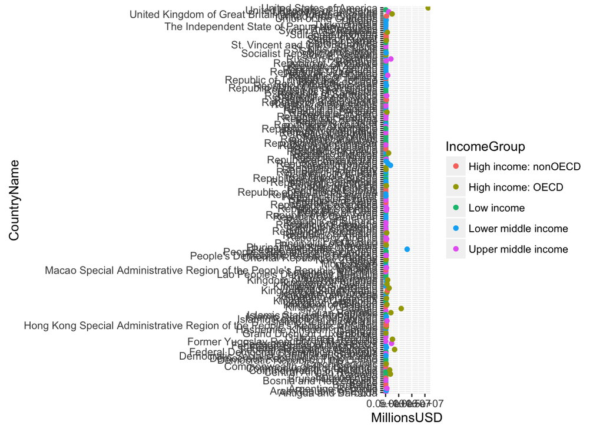

```r
qplot(MillionsUSD, CountryName, data=dataplot, color=IncomeGroup, geom=c("point"))
```

4. Plot using ggplot syntax

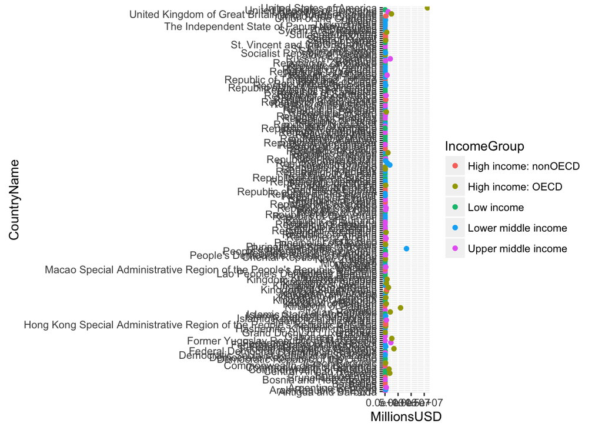

```r
ggplot(data=dataplot, aes(x=MillionsUSD,y=CountryName, color=IncomeGroup))+geom_point()
```

Interpretation of the Plot: United States of America was by far the country with the highest Gross Domestic Product for 2012. Also the countries classified in the Lower Middle Income Group and the Upper Middle Income Group seem to be the majority within the countries for which the GDP for 2012 was analyzed.

# Cut the GDP ranking into 5 separate quantile groups.

1. Create a new dataframe for analysis and review its structure.

```r
dataanalysis <- dataplot
str(dataanalysis)
```

```
## 'data.frame':    189 obs. of  5 variables:
##  $ CountryCode: chr  "TUV" "KIR" "MHL" "PLW" ...
##  $ CountryName: chr  "Tuvalu" "Republic of Kiribati" "Republic of the Marshall Islands" "Republic of Palau" ...
##  $ IncomeGroup: chr  "Lower middle income" "Lower middle income" "Lower middle income" "Upper middle income" ...
##  $ Ranking    : int  190 189 188 187 186 185 184 183 182 181 ...
##  $ MillionsUSD: int  40 175 182 228 263 326 472 480 596 684 ...
```

2. Get the mean and standard deviation of the Ranking variable for further calculations of quantiles

```r
summary(dataanalysis$Ranking)
```

```
##    Min. 1st Qu.  Median    Mean 3rd Qu.    Max.
##    1.00   48.00   95.00   95.31  143.00  190.00
```

```r
sd(dataanalysis$Ranking)
```

```
## [1] 55.06931
```

Mean:95.31

SD:55.06931

3. Calculate quantiles, e.g. the value below which 20 percent of the contries is Ranked

```r
Below20Quantile <- qnorm(0.20, 95.31, 55.06931)
Below20Quantile
```

```
## [1] 48.9625
```

```r
Below40Quantile <- qnorm(0.40, 95.31, 55.06931)
Below40Quantile
```

```
## [1] 81.35835
```

```r
Below60Quantile <- qnorm(0.60, 95.31, 55.06931)
Below60Quantile
```

```
## [1] 109.2617
```

```r
Below80Quantile <- qnorm(0.80, 95.31, 55.06931)
Below80Quantile
```

```
## [1] 141.6575
```

```r
Below99Quantile <- qnorm(.99, 95.31, 55.06931)
Below99Quantile
```

```
## [1] 223.4204
```

```r
dataBelow20Quatile <- dataanalysis[dataanalysis$Ranking <= Below20Quantile, c(1,2,3,4,5)]
dataBelow40Quatile <- dataanalysis[dataanalysis$Ranking <= Below40Quantile, c(1,2,3,4,5)]
dataBelow60Quatile <- dataanalysis[dataanalysis$Ranking <= Below60Quantile, c(1,2,3,4,5)]
dataBelow80Quatile <- dataanalysis[dataanalysis$Ranking <= Below80Quantile, c(1,2,3,4,5)]
dataBelow99Quatile <- dataanalysis[dataanalysis$Ranking <= Below99Quantile, c(1,2,3,4,5)]
```

# Make a table versus Income.Group

```r
table(dataanalysis$Ranking, dataanalysis$IncomeGroup)
```

```
##
##       High income: nonOECD High income: OECD Low income
##   1                      0                 1          0
##   2                      0                 0          0
##   3                      0                 1          0
##   4                      0                 1          0
##   5                      0                 1          0
##   6                      0                 1          0
##   7                      0                 0          0
##   8                      0                 0          0
##   9                      0                 1          0
##   10                     0                 0          0
##   11                     0                 1          0
##   12                     0                 1          0
##   13                     0                 1          0
```

[output cut: 365 more lines]

**How many countries are Lower middle income but among the 38 nations with highest GDP?**

Per the counts in the table above: 5

# Conclusion

1. I really enjoyed working in this case study. It provided a great opportunity to practice many of the R commands we have learned in previous weeks. The instructions also served as a guide to the sequence of events that ultimately allowed for the natural development of the case having a dataflow in the order of raw data -> tidy data -> analyzed data.
2. The ‘technical’ challenges involved in the resolution of the ggplot2 and quantiles questions required additional time and effort but it was gratifying researching and trying more regarding these topics.
3. Here is also a short list that I would like to keep in mind for a future reference:
- Always keep raw data untouched, saved in a separate variable.
- Always maintain sequential variables to hold the progress done at a certain point in time.
- Always before attempting to convert into numeric data type, make sure the values to be converted have discarded any characters such as , $, etc. Otherwise NAs could result upon data type conversion.
- When in doubt and as an optional practice, it is a good idea to open the file in other applications such as MS Excel or Text Edit to verify column headers and the structure of the file.
- Also as part of tidying data, it is recommended to constantly verify the work done over the data to make sure the resultset is as expected. Commands such as head, tail, str, dim, names should be used often.
- It also resulted valuable discarding empty rows while preparing the data for plotting.

# Trying to have some fun

1. If needed install and load the following package:

install.packages(“googleVis”)

library(“googleVis”)

```r
library("googleVis")
```

2. Use the Google gvisGeoChart to map the data based on IncomeGroup

```r
GDPMap <- gvisGeoChart(dataplot, dataplot$CountryCode, dataplot$IncomeGroup)
plot(GDPMap)
```

*Gandrud Christopher, Reproducible research with R and RStudio, CRC Press, 2015 Edition*

*Teutonico Donato, ggplot2 Essentials, Packt Publishing, June 25, 2015*

*Stowell Sarah, Using R for Statistics, Apress, June 29, 2014*